# ggplot bar graphs, maps, and colors

Day 5

## Bar graphs

How does political comfort level (Q9) vary by religious group (Q8)?

[figure not shown]

```r
> levels(survey$Question.8) <- c("not religious","religious, active", "religious, not active")
> ggplot(survey, aes(x=Question.8, fill=Question.9)) + geom_bar(position="fill")
```

## `geom_bar` from summarized data

- The last example plotted survey response data using `geom_bar`
  - each row represented `one` response
  - `ggplot` automatically summarized them for us
- What if our data is already summarized?
  - Below is school district passing percentages by year:

```
# A tibble: 12 × 3
   percent meets           year
     <dbl> <fct>           <chr>
 1    24.5 Exceeds         2015
 2    33.7 Meets           2015
 3    19.4 Partially Meets 2015
 4    22.4 Does not Meet   2015
 5    27.6 Exceeds         2016
 6    32.1 Meets           2016
 7    20.2 Partially Meets 2016
 8    20.2 Does not Meet   2016
 9    26   Exceeds         2017
10    33.7 Meets           2017
11    20.1 Partially Meets 2017
12    20.1 Does not Meet   2017
```

## `geom_bar` from summarized data

- the `percent` variable tells us bar heights (`y`)
- must be paired with `stat="identity"` in `geom_bar`
  - alternatively, can use `geom_col`

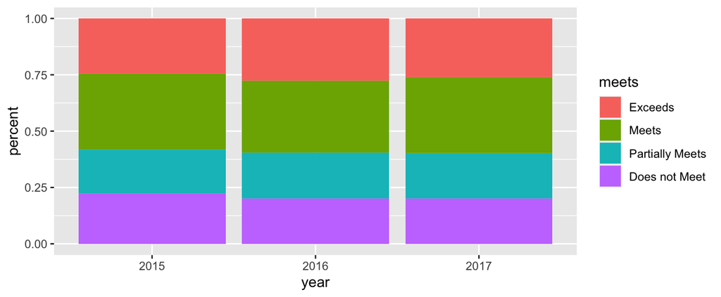

```r
> ggplot(mca, aes(x=year, y=percent, fill=meets)) +
+   geom_bar(stat = "identity", position = "fill")
```

## `ggplot2` maps

The `ggplot2` package contains latitude and longitude to define geographic boundries - some regions: `state`, `usa`, `world`, `county` - see `maps` package for more regions

```r
> MainStates <- map_data("state")
> str(MainStates)
'data.frame':   15537 obs. of  6 variables:
 $ long     : num  -87.5 -87.5 -87.5 -87.5 -87.6 ...
 $ lat      : num  30.4 30.4 30.4 30.3 30.3 ...
 $ group    : num  1 1 1 1 1 1 1 1 1 1 ...
 $ order    : int  1 2 3 4 5 6 7 8 9 10 ...
 $ region   : chr  "alabama" "alabama" "alabama" "alabama" ...
 $ subregion: chr  NA NA NA NA ...
```

## Maps using `geom_path`

`geom_path` connects the dots between lat (`y`) and long (`x`) points in a given `group`

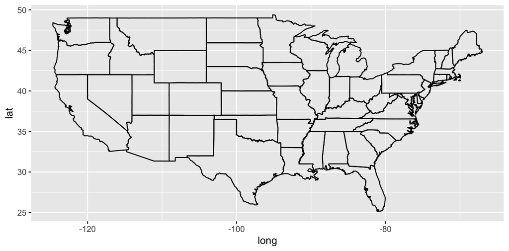

```r
> ggplot(MainStates) +
+     geom_path(aes(x=long, y=lat, group=group))
```

## Maps using `geom_polygon`

`geom_polygon` is like `geom_path` but it connects start and end points which allows you to `fill` a closed polygon shape

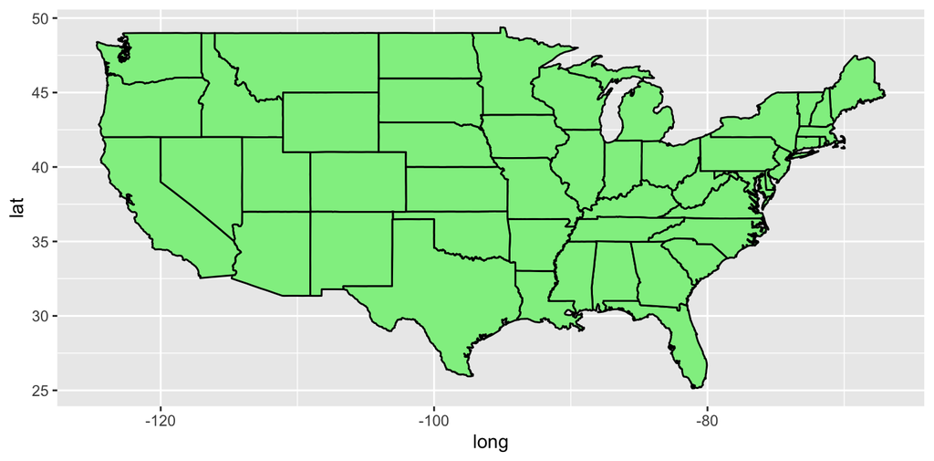

```r
> ggplot(MainStates) +
+     geom_polygon(aes(x=long, y=lat, group=group), color="black", fill="lightgreen")
```

## Spatial data

- Earth is a 3-D object but a map is 2-D
  - spatial projection transforms (projects) lat/long locations on a sphere to a cartesian plane
  - distance between latitude is constant (~69 miles/degree lat)
  - distance between longitude decreases as you approach the poles (~69 miles/degree at equator to 0 miles at poles)
- many possible projections that preserve some feature
  - area, angle, distance, …
- Mercator projection preserves angle but distorts area

## Maps using `coord_quickmap()`

the `coord_quickmap` function provides a Mercator approximation by fixing a lat/long ratio - good for small regions close to equator

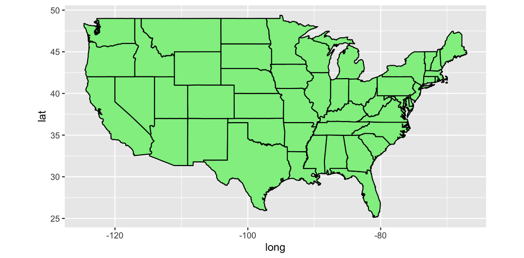

```r
> ggplot(MainStates) +
+     geom_polygon(aes(x=long, y=lat, group=group), color="black", fill="lightgreen") +
+   coord_quickmap()
```

## Maps using `coord_map()`

the `coord_map` function provides a Mercator projection - see `mapproj` package for more projection options

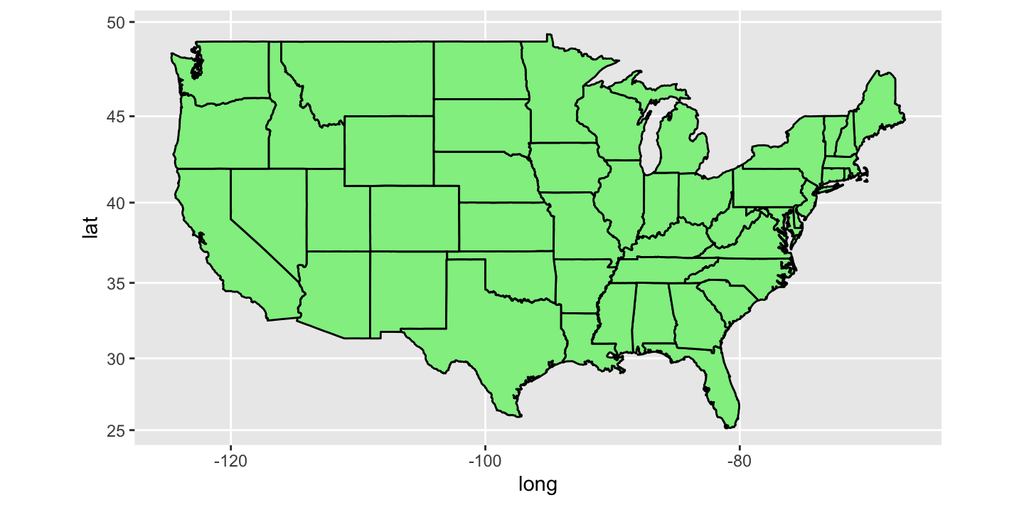

```r
> ggplot(MainStates) +
+     geom_polygon(aes(x=long, y=lat, group=group), color="black", fill="lightgreen") +
+   coord_map()
```

## World with `coord_quickmap`

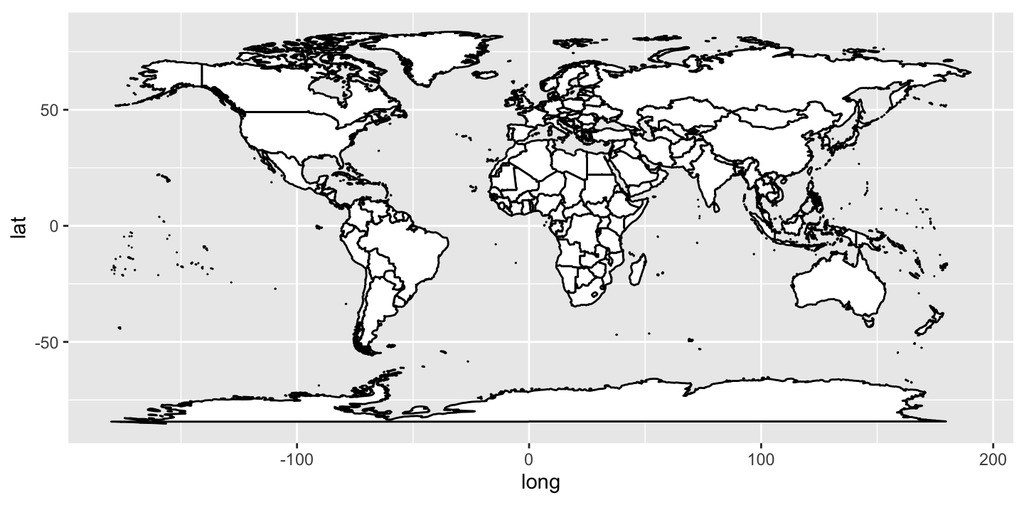

```r
> world <- map_data("world")
> ggplot(world) +
+     geom_polygon(aes(x=long, y=lat, group=group), color="black", fill="white") +
+   coord_quickmap()
```

## World with `coord_map`

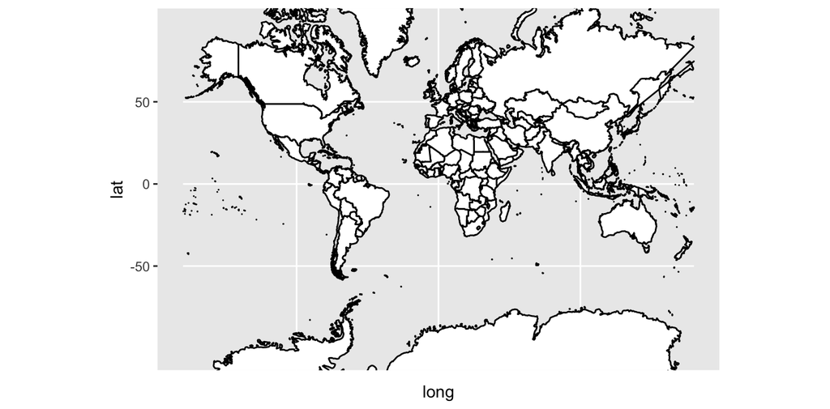

```r
> ggplot(world) +
+     geom_polygon(aes(x=long, y=lat, group=group), color="black", fill="white") +
+   coord_map() + scale_x_continuous(limits=c(-180,180))
```

## Cloropleth maps using `geom_map`

- A cloropleth map uses color or shading of subregions to visual data
- State level data from the 2016 American Community Survey

```r
> ACS <- read.csv("https://raw.githubusercontent.com/mgelman/data/master/ACS2016.csv")
>
> ACS <- ACS[ACS$region != "Alaska" & ACS$region != "Hawaii",] # only 48+D.C.
> ACS$region <- tolower(ACS$region)  # lower case (match MainStates regions)
> str(ACS)
'data.frame':   49 obs. of  7 variables:
 $ region        : chr  "alabama" "arizona" "arkansas" "california" ...
 $ PopSize       : int  4841164 6728577 2968472 38654206 5359295 3588570 934695 659009 19934451 10099320 ...
 $ MedianAge     : num  38.6 37.1 37.7 36 36.4 40.6 39.6 33.8 41.6 36.2 ...
 $ PercentFemale : num  51.5 50.3 50.9 50.3 49.8 51.2 51.6 52.6 51.1 51.3 ...
 $ BornInState   : int  3387845 2623391 1823628 21194542 2294446 1981427 425160 242020 7151459 5562769 ...
 $ MedianIncome  : int  23527 26565 22787 27772 31325 34124 30648 41160 25166 26132 ...
 $ PercentInState: num  70 39 61.4 54.8 42.8 ...
```

## Cloropleth maps using `geom_map`

- Want to visualize “% born in state”
- Don’t need to merge data. Can have two separate data files: state data `ACS` + mapping data `MainStates`

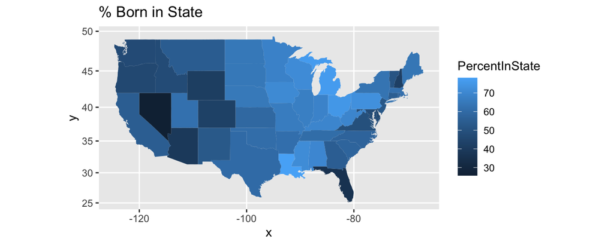

```r
> ggplot() + coord_map() +
+   geom_map(data=ACS, aes(map_id = region, fill = PercentInState), map = MainStates) +
+   expand_limits(x=MainStates$long, y=MainStates$lat) + ggtitle("% Born in State")
```

## Cloropleth maps using `geom_map`

- Add point layer for state capitals in third data set

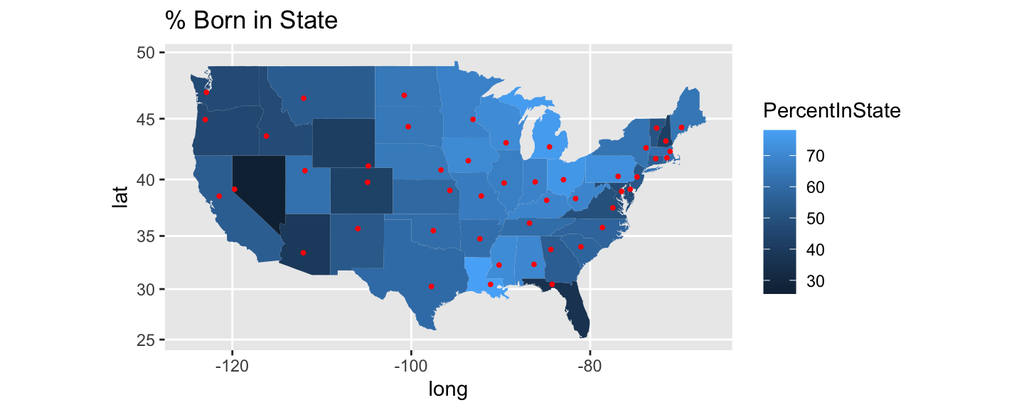

```r
> capitals <- read.csv("https://raw.githubusercontent.com/mgelman/data/master/capitals.csv")
> capitals <- capitals[capitals$state != "Alaska" & capitals$state != "Hawaii",] # only 48
> ggplot(data=ACS) + coord_map() +
+   geom_map(data=ACS, map=MainStates, aes(map_id = region, fill = PercentInState)) +
+    geom_point(data=capitals, aes(x=long,y=lat), size=.7, color="red") +
+   expand_limits(x=MainStates$long, y=MainStates$lat) + ggtitle("% Born in State")
```

## Adjusting color

- When `color=` is a categorical variable, can use `scale_color_brewer()` or `scale_color_manual()` to change color
  - same for `fill` colors (change `color` to `fill`)
  - See textbook page 21 for Brewer color palette names
  - can use base-R colors in `rainbow`, `colors` or `palette` for `manual`
- When `color` is a numeric variable, can use `scale_color_distiller()` for Brewer colors and versions of `scale_color_gradient()` for manual colors
  - sequential colors: for low to high data (one direction)
  - diverging colors: for data with a “middle” (higher or lower than the middle)

## Color for numeric variables

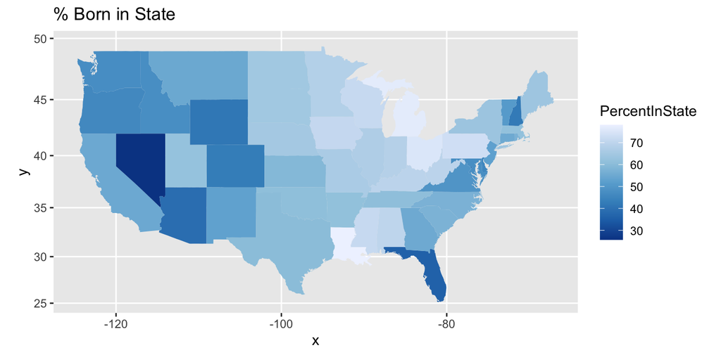

```r
> mymap <- ggplot() + coord_map() +
+   geom_map(data=ACS, aes(map_id = region, fill = PercentInState), map = MainStates) +
+   expand_limits(x=MainStates$long, y=MainStates$lat) + ggtitle("% Born in State")
> mymap + scale_fill_distiller()
```

## Color for numeric variables

- See `?scale_fill_distiller` for `palette` option names

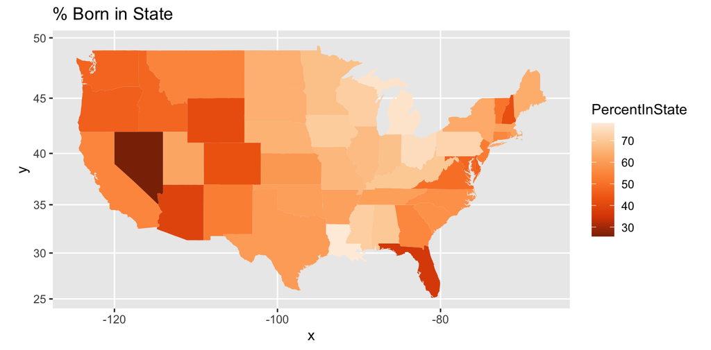

```r
> mymap + scale_fill_distiller(palette = "Oranges")
```

## Color for numeric variables

- Manual choice, see `colors()` for color options

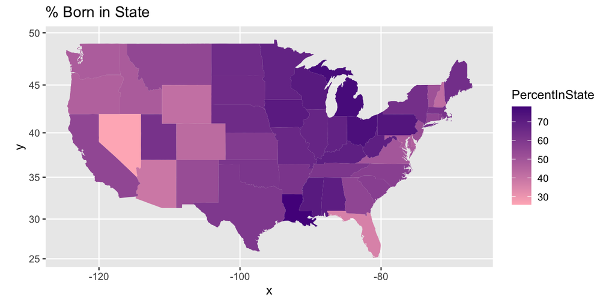

```r
> mymap + scale_fill_gradient(low="lightpink", high="purple4")
```

## Color for numeric variables

- Sometimes we want to look at how numbers deviate from 0
- Let’s look at the difference between state median income and national median income
  - national median income is estimated to be about $27,000 in 2016

```r
> mymap2 <- ggplot() + coord_map() +
+   geom_map(data=ACS, aes(map_id = region, fill = MedianIncome - 27000), map = MainStates) +
+   expand_limits(x=MainStates$long, y=MainStates$lat) + ggtitle("Difference from US median income")
```

## Color for numeric variables

- Sequential choice (default) doesn’t highlight deviations from overall median income

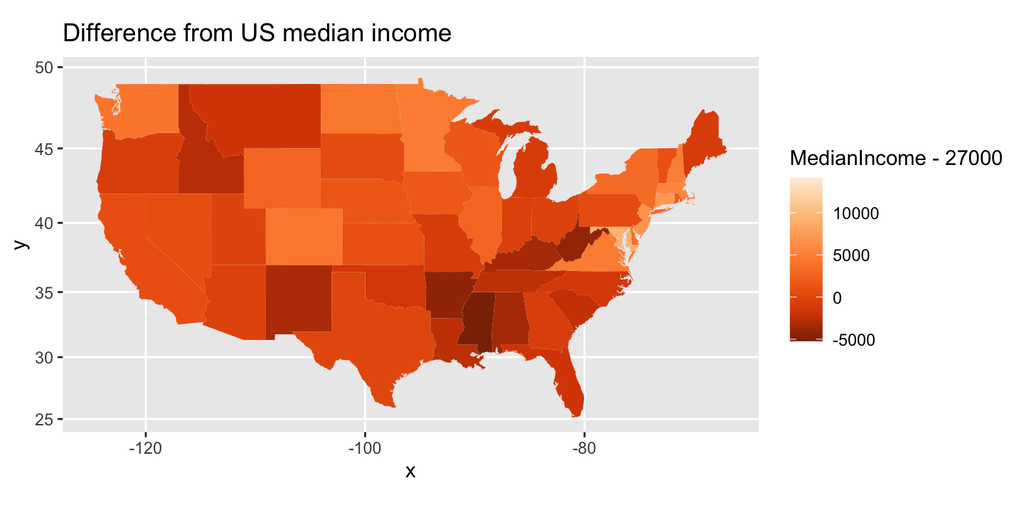

```r
> mymap2 + scale_fill_distiller(palette = "Oranges")
```

## Color for numeric variables

- change `type="div"` and color `palette`

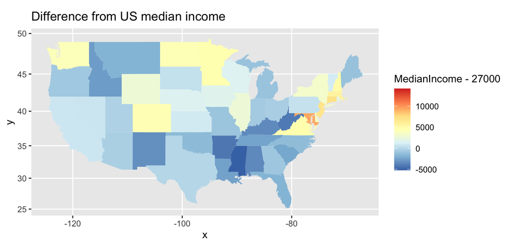

```r
> mymap2 + scale_fill_distiller(type="div", palette = "RdYlBu")
```

## Color for numeric variables

- can switch direction of colors

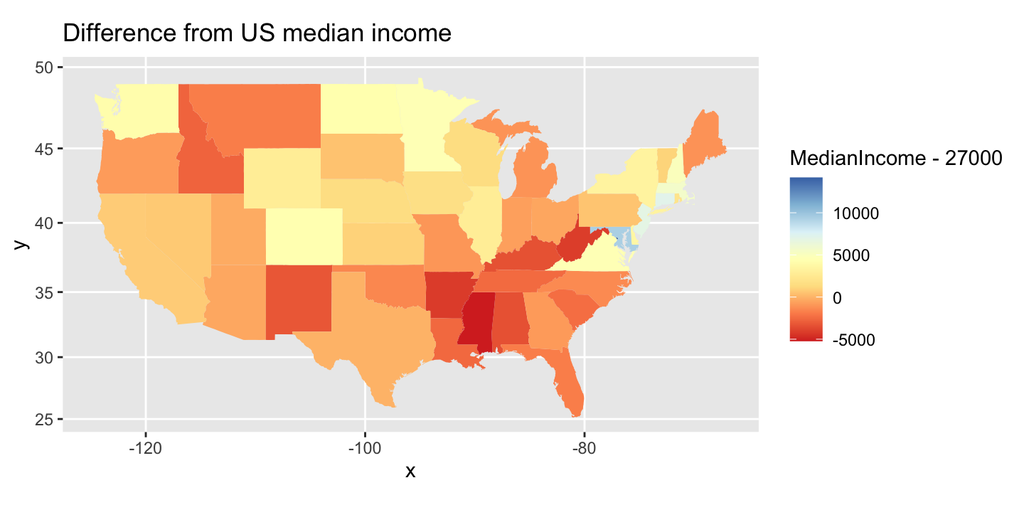

```r
> mymap2 + scale_fill_distiller(type="div", palette = "RdYlBu", direction = 1)
```

## Color for numeric variables

- `gradient2` manually fills diverging colors, can fix mid color

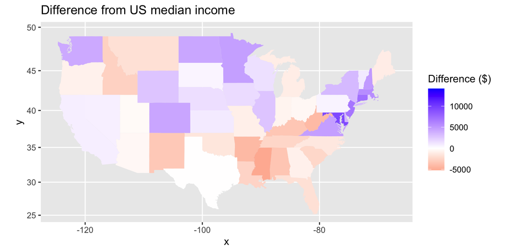

```r
> mymap2 + scale_fill_gradient2(midpoint = 0, low="red", high="blue", name="Difference ($)")
```

## Color for categorical variables

- Another `fill` color used!

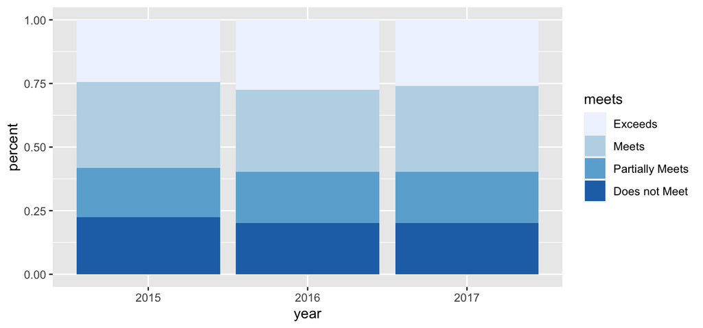

```r
> mybar <- ggplot(mca, aes(x=year, y=percent, fill=meets)) +
+   geom_bar(stat = "identity", position = "fill")
> mybar + scale_fill_brewer()
```

## Color for categorical variables

- Could use a diverging color

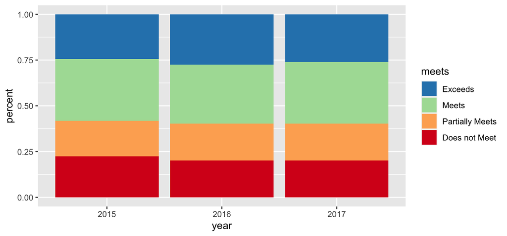

```r
> mybar + scale_fill_brewer(palette = "Spectral", direction=-1)
```

## Color for categorical variables

- can also manually fill colors

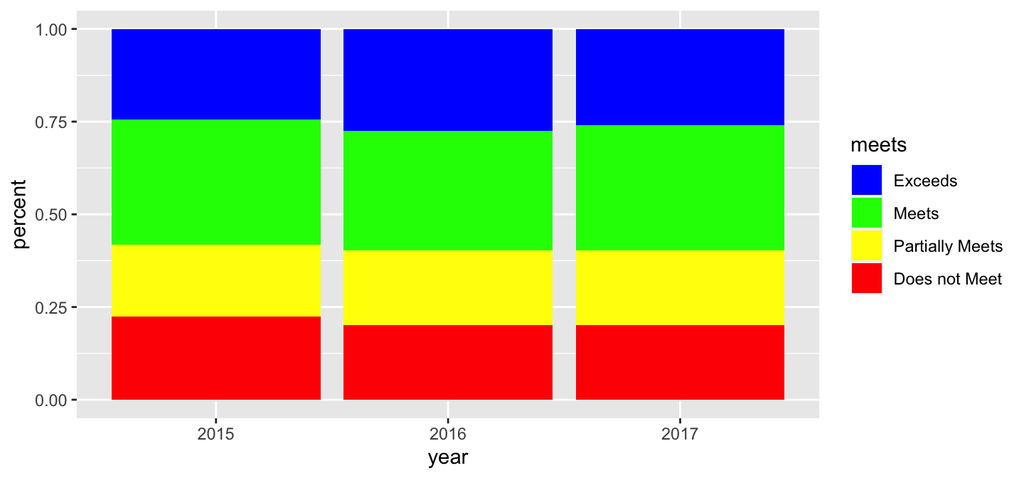

```r
> mybar + scale_fill_manual(values=c("blue", "green","yellow","red"))
```